## About me

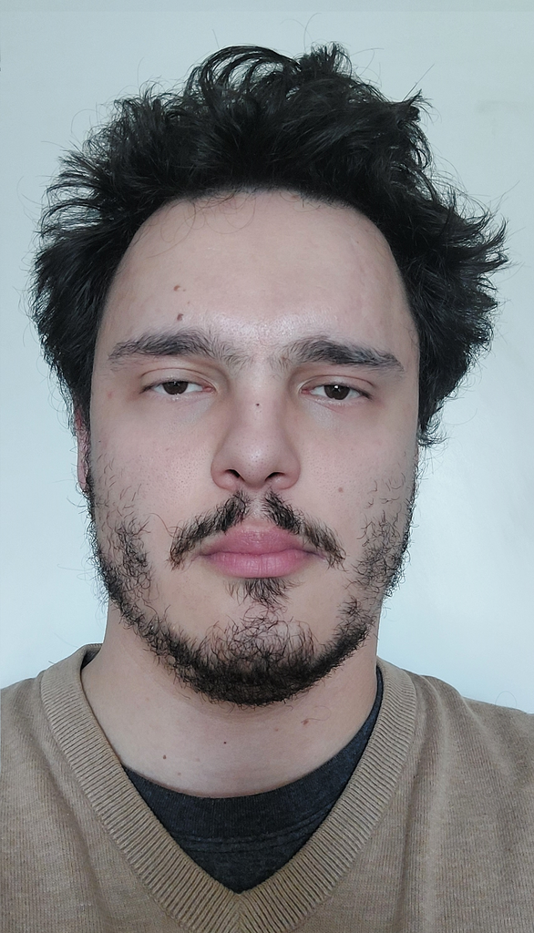

Hi, my name is Gabriel Pistelli Ferreira and I’m a Sociology researcher based in Brazil. Currently, I’ve just finished my Masters and I’m looking for new opportunities to develop my skills and contribute applying my knowledge to different domains of sociology, data science and network with researchers all around the world and contribute to public sociology. I hope to keep this page as a space to link together all my contributions with research, code and new ideas. You can reach me through gabriel.pistelli.ferreira@gmail.com.

I can be found also in:

[Lattes (CV)](http://buscatextual.cnpq.br/buscatextual/visualizacv.do?id=K2138347Y9)

[Github](https://github.com/gpistelli/)

[Kaggle](https://www.kaggle.com/gabrielpistelli)

[Researchgate](https://www.researchgate.net/profile/Gabriel-Pistelli-Ferreira)

[Academia.edu](https://ufpr.academia.edu/GabrielPistelliFerreira)

## Research

Lately, I’ve been focusing my research in basically three main objects: a) Brazilian Industrialists and their political and economic ideologies, with a special focus in 2017 Brazilian Labor Reform; b) Industrialists’ collective action, focusing more on their division inside their associations and social composition; and c) new methods inspired from Data Science to apply into social sciences research. All my research has been heavily influenced by Marxist and Bourdieusian researchers, and my theoretical position is to find a creative combination between these two different paradigms. I’m interested in studying social classes, collective action, elites and inequalities through innovative methods and new perspectives.

### Master Thesis

My master thesis focused in understanding the effects of Brazilian 2017 Labor Reform in employers unions collective action and the peculiarities of their collective action through a mixed methods approach, mixing interviews, survey, GDA and SNA.

[(2021) Complexo associativo da indústria e a reforma trabalhista de 2017: um estudo do espaço social dos sindicatos patronais da indústria do Paraná. UFPR](https://acervodigital.ufpr.br/handle/1884/74947) | [Github Repo](https://github.com/gpistelli/comp-assoc-ind-ref-trab) | [Academia.edu](https://www.academia.edu/79578263/Complexo_associativo_da_ind%C3%BAstria_e_a_reforma_trabalhista_de_2017) | [Researchgate](https://www.researchgate.net/publication/360571539_Complexo_associativo_da_industria_e_a_reforma_trabalhista_de_2017_um_estudo_do_espaco_social_dos_sindicatos_patronais_da_industria_do_Parana)

### Bachelor Thesis

A content analysis of CNI (National Industrialists Confederation) discourse about Labor Reform in Brazil and their political and economic ideologies during the 2002-2017 timeline.

(2017) “Não fale em crise, trabalhe”: o discurso da CNI sobre a reforma trabalhista. UFPR | [Academia.edu](https://www.academia.edu/79579467/_N%C3%A3o_fale_em_crise_trabalhe_o_discurso_da_CNI_sobre_a_moderniza%C3%A7%C3%A3o_trabalhista) | [Researchgate](https://www.researchgate.net/publication/360568984_NAO_FALE_EM_CRISE_TRABALHE_O_DISCURSO_DA_CNI_SOBRE_A_MODERNIZACAO_TRABALHISTA)

### Chapters

[(2021) O grande empresariado diante da pandemia da COVID-19 no Brasil: para uma agenda de pesquisa sobre a organização das classes dominantes no contexto neoliberal. In: COSTA, Alexandre Bernardino; CARVALHO, Claudiane Silva. (Org.). Desigualdade, crise sanitária e direitos. 1ed.Rio de Janeiro: Lumen Juris, 2021, p. 171-202](https://www.amazon.com.br/dp/B098FDSFPX/ref=cm_sw_r_wa_awdb_WNFDFWZJZ1GDG18EDXAH)

### Working Papers

(2021) Empresários e sindicatos patronais no associativismo empresarial paranaense: perfil e trajetórias dos representantes das indústrias de Curitiba. GT 14 do 45º Encontro da ANPOCS

[(2019) Novo espírito capitalista, novo modelo de desenvolvimento? Sobre a conversão da indústria ao neoliberalismo. GT 1 do 11º Encontro da ABET](https://www.abet2019.sinteseeventos.com.br/simposio/view?ID_SIMPOSIO=8)

## Data Science

Another pretty significant part of my activities is trying to analyze and share data for scientific divulgation purposes and provide democratic access to data while contributing to new methods of research and developing my programming skills. For now, I’m relatively experienced in using R and I’m also starting to develop better my Python skills. I’m especially focused in Geometric Data Analysis, Social Network Analysis, Scraping, NLP, Classification and some others Machine Learning algorithms, without losing our focus in an inferential approach to statistics.

### Finished

[Consultasocio Package: A package to study business owners capital composition (2022)](https://gpistelli.github.io/Consultasocio/) | [Github Repo](https://github.com/gpistelli/Consultasocio)

[MediadoR Package: A Tool to Research Brazilian Collective Bargaining (2022)](https://gpistelli.github.io/MediadoR/) | [Github Repo](https://github.com/gpistelli/MediadoR)

[Análise Geométrica das votações na câmara dos deputados (2019-2022)](https://gpistelli.github.io/BR-congress-votes/) | [Github Repo](https://github.com/gpistelli/BR-congress-votes)

[Notas taquigráficas da CPI da Pandemia (2021)](https://www.kaggle.com/datasets/gabrielpistelli/notas-taquigrficas-da-cpi-da-covid)